# Time Series Analysis and Model Diagnostics

### Standardized Residuals from Log Oil Price IMA(1,1) Model

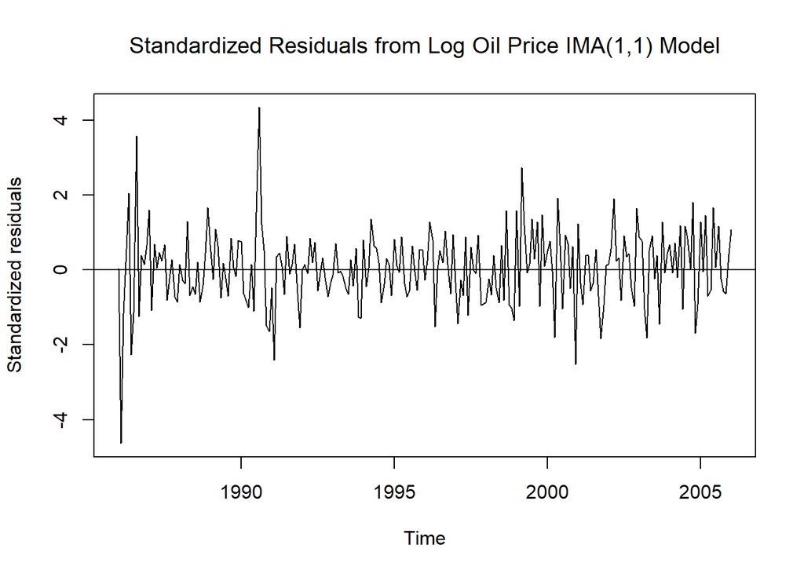

```r
data(oil.price)
m1.oil=arima(log(oil.price),order=c(0,1,1))

plot(rstandard(m1.oil),ylab='Standardized residuals',type='l',
main = expression("Standardized Residuals from Log Oil Price IMA(1,1) Model"))
abline(h=0)
```

This time series plot displays the **standardized residuals** from the IMA(1,1) model fitted to the **log-transformed oil price data**.

- The residuals mostly fluctuate around **zero**, suggesting the model captures the general structure of the data.
- However, several notable **spikes** are observed, particularly in the earlier years (e.g., late 1980s and early 1990s), indicating the presence of **outliers** or volatility that the model may not fully explain.
- The variance of residuals appears **non-constant** over time (heteroscedasticity), with larger deviations in earlier periods — a potential signal for **model misspecification** or **structural changes** in the data.
- No strong evidence of residual drift, which supports the suitability of the differencing component (d=1).

These observations suggest that while the IMA(1,1) model performs reasonably well, further improvements may involve volatility modeling (e.g., **GARCH models**) or adding exogenous variables.

### Q-Q Plot of Residuals from AR(1) Color Model

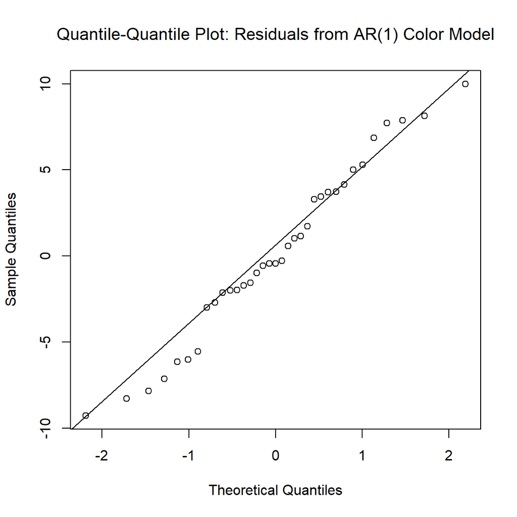

```r
qqnorm(residuals(m1.color),
main=expression("Quantile-Quantile Plot: Residuals from AR(1) Color Model"))
qqline(residuals(m1.color))
```

- The points generally align with the **45-degree reference line**, especially in the center, indicating that the residuals are approximately **normally distributed**.
- There are some mild deviations in the tails, suggesting **slight departures from normality** (e.g., potential outliers or heavier tails).
- This overall supports the **validity of the AR(1) model**’s residual assumptions, though caution should be taken if formal inference is sensitive to tail behavior.

The normality assumption appears **reasonably satisfied**, reinforcing confidence in the model diagnostics.

### Q-Q Plot of Residuals from AR(3) Model for Hare Data

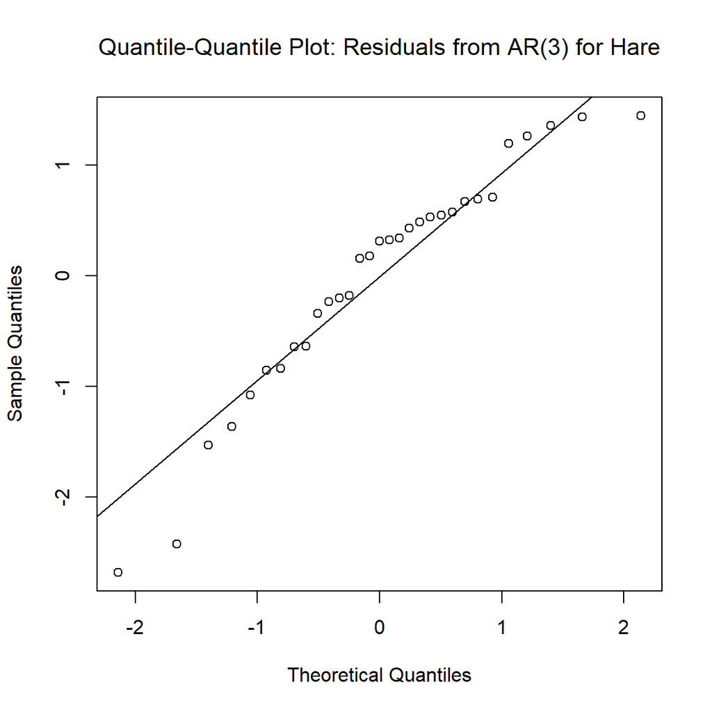

```r
qqnorm(residuals(m1.hare),
main=expression("Quantile-Quantile Plot: Residuals from AR(3) for Hare"))
qqline(residuals(m1.hare))
```

This quantile-quantile (Q-Q) plot evaluates whether the **residuals** from the AR(3) model fitted to the **square-root-transformed hare abundance data** are approximately normally distributed.

- The points mostly fall along the 45-degree reference line, especially around the **center quantiles**, suggesting a generally good fit to the normal distribution.
- Minor deviations are observed at the **extreme tails**, which is common and not necessarily problematic unless strong normality is crucial for inference.
- Overall, the residuals appear to follow a **roughly normal distribution**, validating the model’s assumption of **Gaussian noise**.

This plot supports the **adequacy of the AR(3) model** from a normality diagnostic perspective.

### Q-Q Plot of Residuals from IMA(1,1) Model for Oil Prices

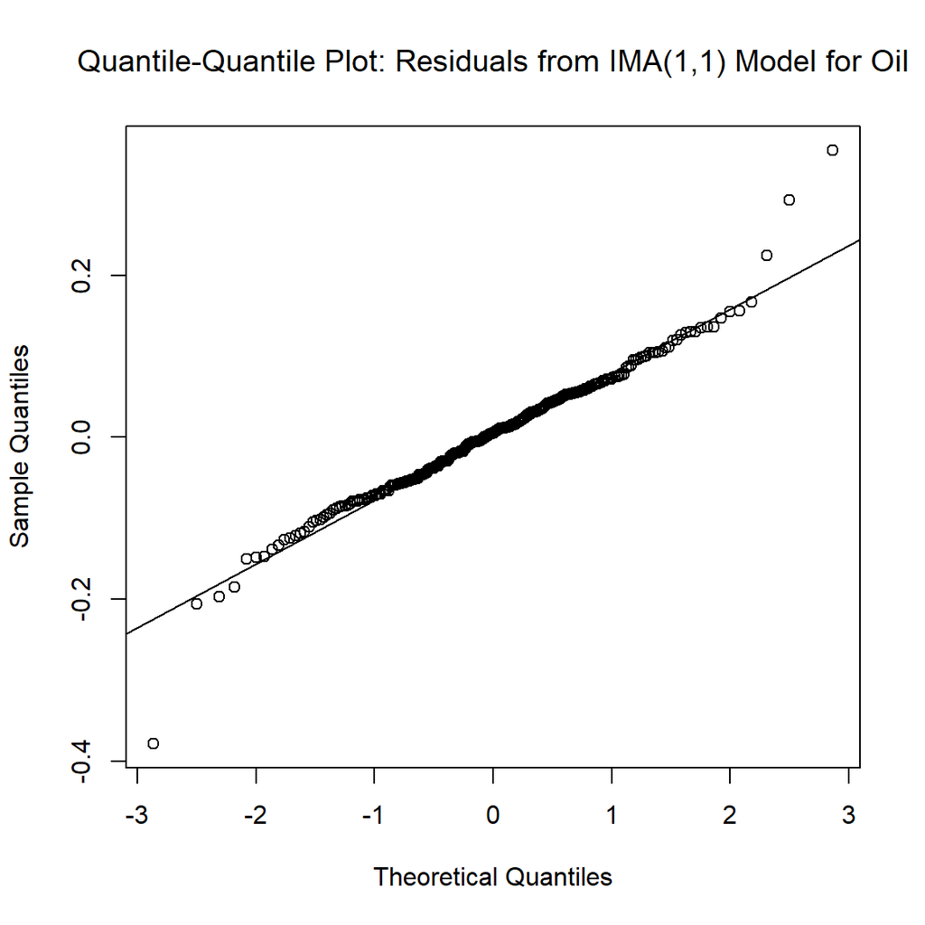

```r
qqnorm(residuals(m1.oil),
main=expression("Quantile-Quantile Plot: Residuals from IMA(1,1) Model for Oil"))
qqline(residuals(m1.oil))
```

This Q-Q plot assesses the **normality of residuals** from the IMA(1,1) model fitted to the **log-transformed oil price data**.

### ACF of Residuals from AR(1) Model for Color

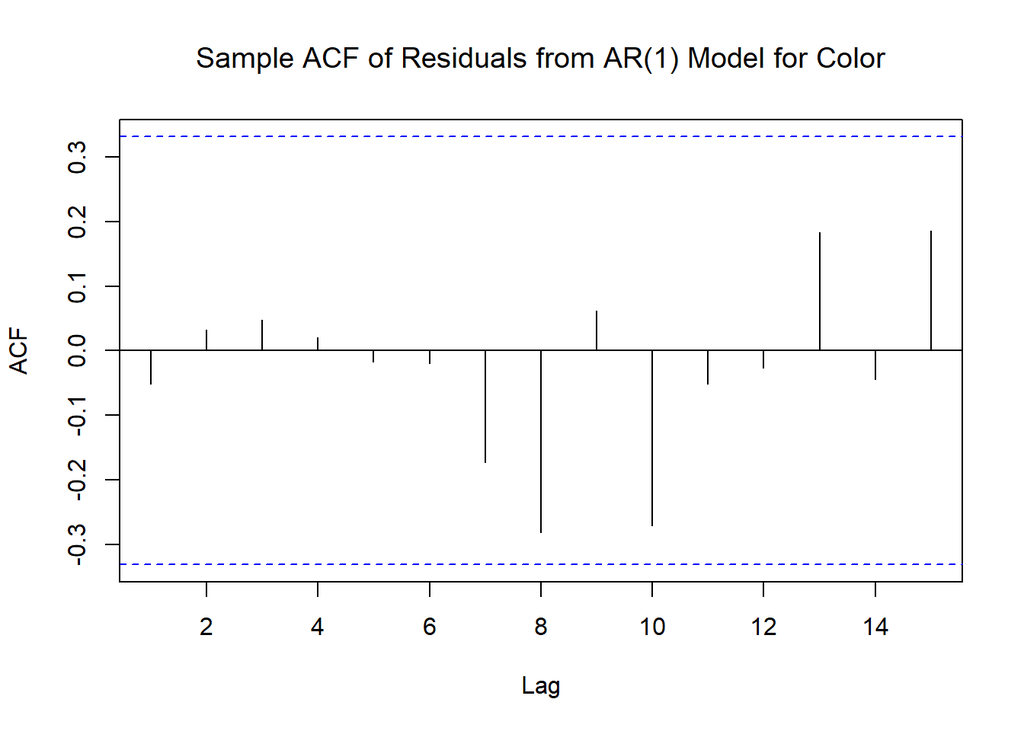

```r
acf(residuals(m1.color),
main = expression("Sample ACF of Residuals from AR(1) Model for Color"))
```

This plot shows the **sample autocorrelation function (ACF)** of the residuals from the AR(1) model fitted to the `color` dataset.

This is a good diagnostic check for verifying the **model assumptions** of uncorrelated residuals.

[figure not shown]

```r
acf(residuals(m1.color),
main = expression("Sample ACF of Residuals from AR(2) Model for Hare"))
```

### Residual Autocorrelations (Lags 1–6) from AR(1) Model for Color

```r
acf(residuals(m1.color),plot=F)
```

```
##
## Autocorrelations of series 'residuals(m1.color)', by lag
##
##      1      2      3      4      5      6      7      8      9     10     11
## -0.051  0.032  0.047  0.021 -0.017 -0.019 -0.173 -0.281  0.061 -0.270 -0.051
##     12     13     14     15
## -0.027  0.183 -0.044  0.186
```

```r
signif(acf(residuals(m1.color),plot=F)$acf[1:6],2)
```

```
## [1] -0.051  0.032  0.047  0.021 -0.017 -0.019
```

The first six autocorrelation values of the residuals from the AR(1) model fitted to the `color` dataset are:

| Lag | ACF Value |
| --- | --- |
| 1 | -0.051 |
| 2 | 0.032 |
| 3 | 0.047 |
| 4 | 0.021 |
| 5 | -0.017 |
| 6 | -0.019 |

- These values are **all small in magnitude**, and **none exceed ±0.2**, suggesting **minimal autocorrelation** in the residuals.
- This indicates that the **AR(1) model has successfully removed the linear dependence** in the data up to lag 6.
- Notably, the largest deviations occur **after lag 6**, especially at **lags 8 and 10**, as seen in the full ACF output.

This summary supports the **adequacy of the AR(1) model**, although further lags could be examined to rule out structure beyond lag 6.

### Diagnostic Display for the AR(1) Model of Color

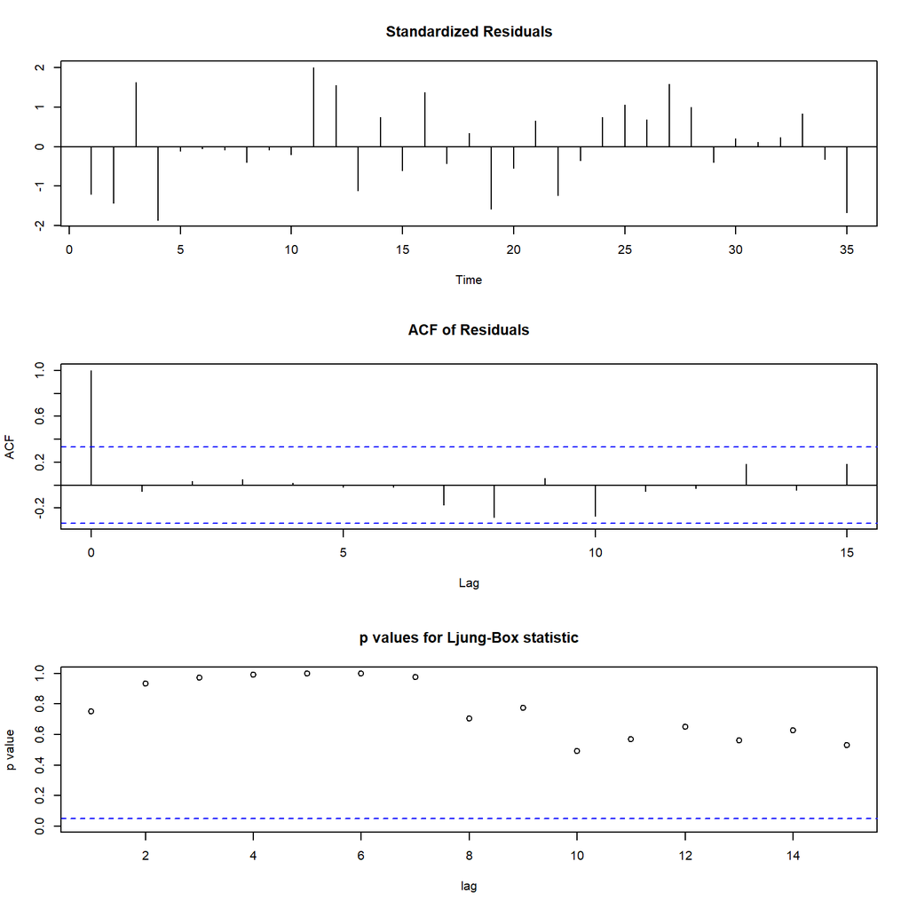

```r
tsdiag(m1.color,gof=15,omit.initial=F,
main = expression("Diagnostic Display for the AR(1) Model of Color Property"))
```

This diagnostic display contains three panels:

#### 1. Standardized Residuals

- The top panel shows standardized residuals over time.
- Most values hover around zero with no apparent trend or seasonality.
- A few residuals approach ±2, which may suggest mild outliers, but overall behavior is consistent with white noise.

#### 2. ACF of Residuals

- The middle panel shows the autocorrelation function (ACF) of residuals.
- All lags are within the 95% confidence bounds (blue dashed lines).
- This suggests no significant autocorrelation remaining in the residuals, indicating a good model fit.

#### 3. Ljung-Box Test p-values

- The bottom panel plots the p-values of the Ljung–Box test up to lag 15.
- Most p-values exceed the 0.05 threshold, so we fail to reject the null hypothesis of independence.
- This further supports that residuals are approximately white noise.

### Conclusion

All diagnostics suggest that the AR(1) model provides an adequate fit to the `color` time series data.

### AR(1) Model Results for the ‘Color’ Property Series

```r
m1.color
```

```
##
## Call:
## arima(x = color, order = c(1, 0, 0))
##
## Coefficients:
##          ar1  intercept
##       0.5705    74.3293
## s.e.  0.1435     1.9151
##
## sigma^2 estimated as 24.83:  log likelihood = -106.07,  aic = 216.15
```

**Interpretation:**

- The fitted model is an **AR(1)** process with one autoregressive term and no differencing or MA terms.
- The AR(1) coefficient is **0.5705**, indicating moderate positive autocorrelation.
- The **intercept** is estimated at **74.33**.
- The **standard errors** (s.e.) indicate the uncertainty in these estimates.
- The **residual variance** (`sigma^2`) is **24.83**, and the **log-likelihood** is **-106.07**.
- The **Akaike Information Criterion (AIC)** is **216.15**, which is useful for comparing models.

This model will serve as the baseline for subsequent diagnostic evaluation.

### AR(2) Model Results for the Color Property Series

```r
arima(color,order=c(2,0,0))
```

```
##
## Call:
## arima(x = color, order = c(2, 0, 0))
##
## Coefficients:
##          ar1     ar2  intercept
##       0.5173  0.1005    74.1551
## s.e.  0.1717  0.1815     2.1463
##
## sigma^2 estimated as 24.6:  log likelihood = -105.92,  aic = 217.84
```

The AR(2) model estimates for the color property series indicate moderate autoregressive behavior at lags 1 and 2. The coefficient $\phi_1 = 0.5173$ is statistically significant given its standard error of 0.1717, suggesting a strong positive correlation with the previous value. The second coefficient $\phi_2 = 0.1005$ is smaller in magnitude and less clearly distinguishable from zero due to its standard error of 0.1815, implying a weaker or possibly negligible influence from the second lag.

The intercept term of approximately 74.16 represents the mean-adjusted level of the time series under this model. The residual variance ($\hat{\sigma}^2$) is estimated to be 24.6, slightly lower than that of the AR(1) model previously fitted, suggesting a marginal improvement in model fit.

However, the Akaike Information Criterion (AIC) for this AR(2) model is 217.84, which is slightly higher than the AIC of the AR(1) model (216.15), indicating that adding the second lag may not lead to a significantly better model in terms of overall fit-to-complexity tradeoff.

### Overfit of an ARMA(1,1) Model for the Color Series

```r
arima(color,order=c(1,0,1))
```

```
##
## Call:
## arima(x = color, order = c(1, 0, 1))
##
## Coefficients:
##          ar1      ma1  intercept
##       0.6721  -0.1467    74.1730
## s.e.  0.2147   0.2742     2.1357
##
## sigma^2 estimated as 24.63:  log likelihood = -105.94,  aic = 217.88
```

This ARMA(1,1) model attempts to capture both autoregressive and moving average components in the color property series. The estimated AR(1) coefficient $\phi_1 = 0.6721$ is relatively large and suggests strong positive autocorrelation at lag 1, though its standard error (0.2147) indicates moderate uncertainty. The MA(1) coefficient $\theta_1 = -0.1467$ is smaller in magnitude and not clearly distinguishable from zero given its standard error (0.2742), implying a weak or negligible moving average component.

In terms of model selection criteria, the AIC of 217.88 is marginally higher than both the AR(1) and AR(2) models, suggesting that including both AR and MA components does not improve the fit enough to justify the increased complexity.

### Overfitted ARMA(2,1) Model for the Color Property Series

```r
arima(color,order=c(2,0,1))
```

```
##
## Call:
## arima(x = color, order = c(2, 0, 1))
##
## Coefficients:
##          ar1     ar2     ma1  intercept
##       0.2189  0.2735  0.3036    74.1653
## s.e.  2.0056  1.1376  2.0650     2.1121
##
## sigma^2 estimated as 24.58:  log likelihood = -105.91,  aic = 219.82
```

The ARMA(2,1) model includes two autoregressive terms and one moving average term. However, none of the estimated coefficients are statistically significant due to extremely large standard errors (e.g., $\text{SE}_{\phi_1} = 2.0056$ and $\text{SE}_{\theta_1} = 2.0650$), which far exceed the magnitudes of the coefficients themselves. This suggests a high level of estimation uncertainty and potentially multicollinearity or model overparameterization.

The residual variance is estimated at 24.58, and the AIC is 219.82—**the highest among all candidate models so far**. Despite slightly improving variance over some simpler models, the lack of precision and increased complexity indicate that this ARMA(2,1) model is **not a preferable fit** for the color property series. Simpler models like AR(1) or AR(2) are likely more interpretable and statistically reliable in this case.

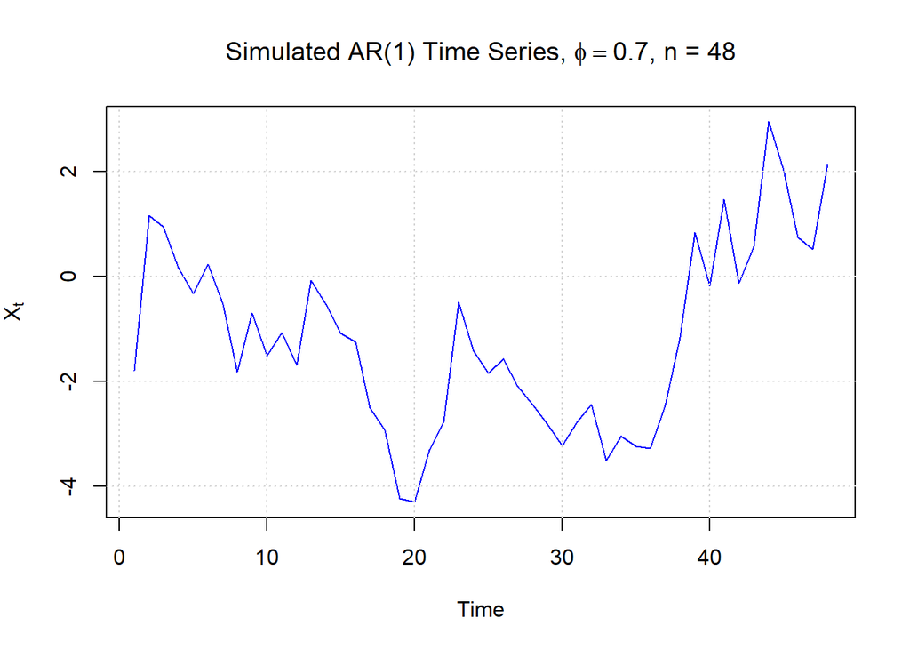

```r
set.seed(1234)
n <- 48
phi <- 0.7
x <- arima.sim(model = list(ar = phi), n = n, sd = 1)
plot(x, type = "l",
     main = expression("Simulated AR(1) Time Series, " * phi == 0.7 * ", n = 48"),
     xlab = "Time", ylab = expression(X[t]),col = "blue")
grid()
```

For an AR(1) process, the theoretical autocorrelation at lag $k$ is:

$$\rho_k = \phi^k$$

Thus, the theoretical autocorrelations at lag 1 and lag 5 for this model are as follows,

$$\rho_1 = 0.7, \quad \rho_5 \approx 0.168$$

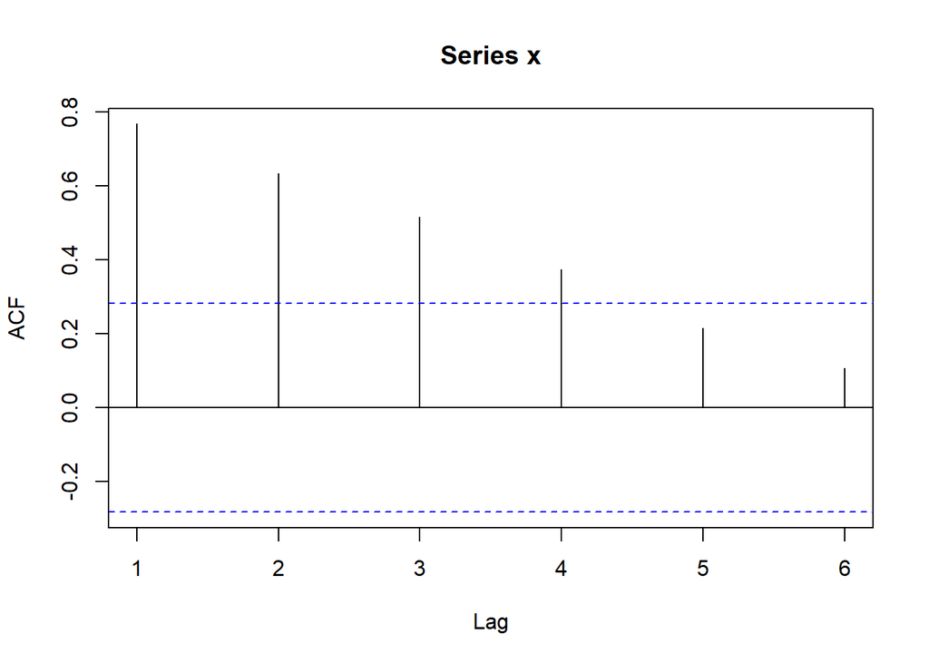

```
##
## Autocorrelations of series 'x', by lag
##
##     1     2     3     4     5     6
## 0.768 0.635 0.516 0.375 0.215 0.107
```

```r
set.seed(1234)
n <- 48
phi <- 0.7
x <- arima.sim(model = list(ar = phi), n = n, sd = 1)
acf_x <- acf(x, lag.max = 6, plot = TRUE); acf_x
```

```r
r1 <- acf_x$acf[1]
r5 <- acf_x$acf[5]
r1; r5
```

```
## [1] 0.7683024
```

```
## [1] 0.2151106
```

We simulate a realization of the AR(1) process with:
$$n = 48, \quad \phi = 0.7$$

The model is:
$$X_t = 0.7 X_{t-1} + e_t, \quad \text{where } e_t \sim \mathcal{N}(0,1)$$

Using R, we simulate the series and compute $r_1$ and $r_5$.

The sample autocorrelations are:
$$r_1 = 0.768, \quad r_5 = 0.215$$

Both $r_1$ and $r_5$ are within 2 standard errors of $\rho_1$ and $\rho_5$ (95% confidence intervals: $\pm 0.206$ for $r_1$, $\pm 0.494$ for $r_5$), indicating that the sample estimates are consistent with the theoretical values within expected variability.

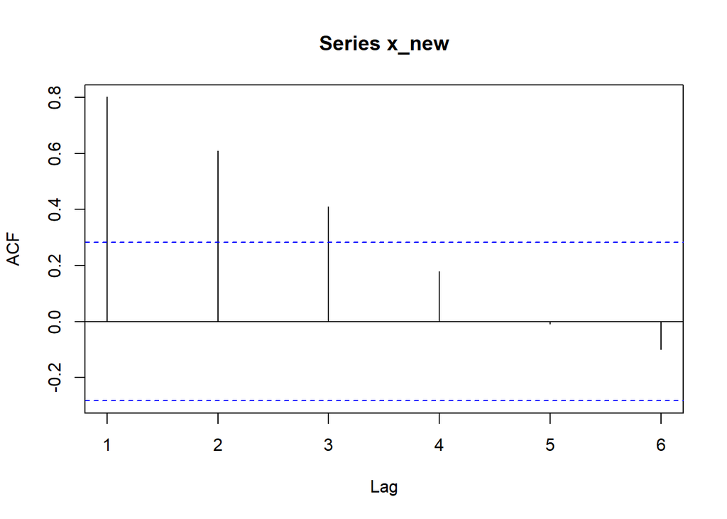

```r
set.seed(5678)
n <- 48
phi <- 0.7
x_new <- arima.sim(model = list(ar = phi), n = n, sd = 1)
acf_x_new <- acf(x_new, lag.max = 6, plot = TRUE)
```

```r
acf_x_new
```

```
##
## Autocorrelations of series 'x_new', by lag
##
##      1      2      3      4      5      6
##  0.802  0.610  0.410  0.180 -0.008 -0.100
```

```r
r1_new <- acf_x_new$acf[1] ;r1_new
```

```
## [1] 0.8016367
```

```r
r5_new <- acf_x_new$acf[5] ;r5_new
```

```
## [1] -0.008202358
```

The new simulated AR(1) process produced the following sample autocorrelations:

$$r_1 = 0.8016, \quad r_5 = -0.0082$$

For an AR(1) process with $\phi = 0.7$, the theoretical autocorrelations are:

$$\rho_1 = \phi = 0.7, \quad \rho_5 = \phi^5 = 0.7^5 = 0.1681$$

The standard errors are calculated as follows:

- **For $r_1$:**

$$\text{Var}(r_1) = \frac{1 - \phi^2}{n} = \frac{1 - 0.7^2}{48} =
\frac{0.51}{48} \approx 0.010625$$

$$\text{SE}(r_1) = \sqrt{0.010625} \approx 0.1031$$

- **For $r_5$:**

Using the corrected formula:

$$\text{Var}(r_5) = \frac{1}{n} \left( \frac{1 + \phi^2}{1 - \phi^2}
\right)$$

First, calculate the sum:

$$\frac{1 + \phi^2}{1 - \phi^2} = \frac{1 + 0.49}{1 - 0.49} =
\frac{1.49}{0.51} \approx 2.9216$$

Now calculate the variance:

$$\text{Var}(r_5) = \frac{1}{48} \times 2.9216 \approx 0.0609$$

$$\text{SE}(r_5) = \sqrt{0.0609} \approx 0.2467$$

- **For $r_1$:**

$$\text{Difference} = r_1 - \rho_1 = 0.8016 - 0.7 = 0.1016$$

$$\text{In Standard Errors} = \frac{0.1016}{0.1031} \approx 0.985$$

This means that $r_1$ is within about $0.985$ standard errors of the theoretical value.

- **For $r_5$:**

$$\text{Difference} = r_5 - \rho_5 = -0.0082 - 0.1681 = -0.2501$$

$$\text{In Standard Errors} = \frac{-0.2501}{0.2467} \approx -1.0138$$

This means that $r_5$ is within about $1.01$ standard errors of the theoretical value.

- In part (b), we had: $r_1 = 0.768$, which was within $0.66$ standard errors of the theoretical value ($0.7$). $r_5 = 0.215$, which was within $0.19$ standard errors of the theoretical value ($0.168$).
- In part (c), for the new simulation: $r_1 = 0.8016$, which is again within $0.985$ standard errors of the theoretical value. $r_5 = -0.0082$, which is also within $1.0138$ standard errors of the theoretical value.

We simulate an MA(1) time series with $n = 60$ and $\theta = 0.5$, defined by:
$$X_t = e_t + \theta e_{t-1},
\quad \text{where } e_t \sim \mathcal{N}(0, 1)$$

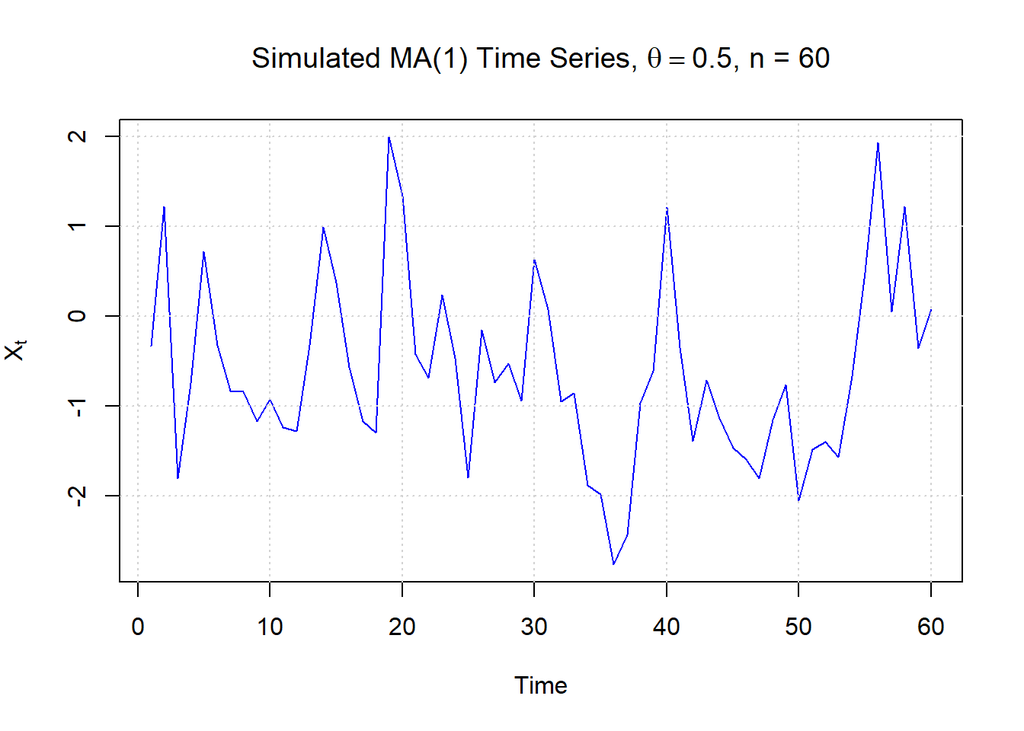

```r
set.seed(1234)
n <- 60
theta <- 0.5
x <- arima.sim(model = list(ma = theta), n = n, sd = 1)

plot(x, type = "l",
     main = expression("Simulated MA(1) Time Series, " * theta == 0.5 * ", n = 60"),
     xlab = "Time", ylab = expression(X[t]),col = "blue")
grid()
```

For an MA(1) process, the theoretical autocorrelation $\rho_k$ is:

$$\rho_k =
\begin{cases}
\frac{\theta}{1 + \theta^2} & \text{if } k = 1, \\
0 & \text{if } k > 1
\end{cases}$$
For $k = 1$ and $\theta = 0.5$:

$$\rho_1 = \frac{\theta}{1 + \theta^2} = \frac{0.5}{1 + 0.5^2} =
\frac{0.5}{1 + 0.25} = \frac{0.5}{1.25} = 0.4$$

Thus, the theoretical autocorrelation at lag 1 is:

$$\rho_1 = 0.4$$

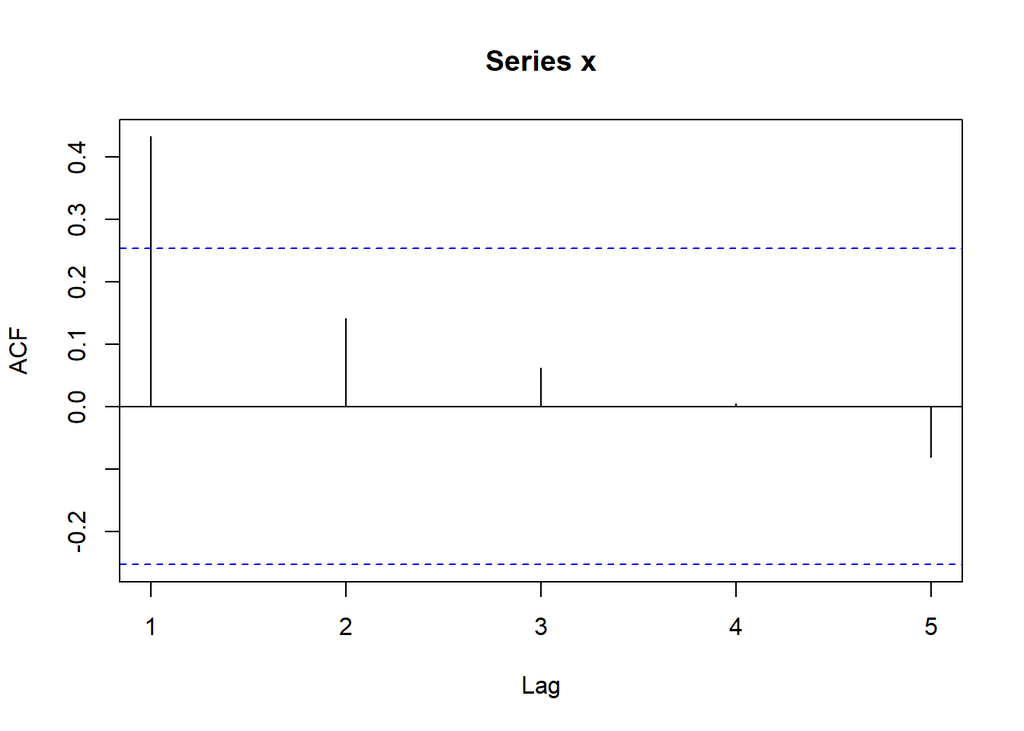

```
##
## Autocorrelations of series 'x', by lag
##
##      1      2      3      4      5
##  0.432  0.141  0.062  0.005 -0.081
```

```r
set.seed(1234)
n <- 60
theta <- 0.5
x <- arima.sim(model = list(ma = theta), n = n, sd = 1)
acf_x <- acf(x, lag.max = 5, plot = TRUE);acf_x
```

```r
r1 <- acf_x$acf[1];r1
```

```
## [1] 0.4319655
```

For an MA(1) process, the theoretical autocorrelation at lag 1 is given by:

$$\rho_1 = \frac{\theta}{1 + \theta^2}$$

With $\theta = 0.5$, we calculate:

$$\rho_1 = \frac{0.5}{1 + 0.5^2} = \frac{0.5}{1.25} = 0.4$$

Thus, the theoretical value of $\rho_1$ is:

$$\rho_1 = 0.4$$

From the R simulation, the sample autocorrelation at lag 1 is:

$$r_1 = 0.4319655$$

From Exhibit 6.2, for $\theta = 0.5$, the standard error of the sample autocorrelation $r_1$ is given by:

$$\text{SE}(r_1) = \frac{0.79}{\sqrt{n}} = \frac{0.79}{\sqrt{60}} \approx
0.102$$

Now, we compare the sample autocorrelation $r_1 = 0.4319655$ with the theoretical value $\rho_1 = 0.4$ using the standard error:

$$\text{Difference} = r_1 - \rho_1 = 0.4319655 - 0.4 = 0.0319655$$

We can express this difference in terms of the standard error:

$$\frac{\text{Difference}}{\text{SE}(r_1)} = \frac{0.0319655}{0.102}
\approx 0.313$$

The difference between the sample autocorrelation $r_1$ and the theoretical value $\rho_1$ is about 0.03197, which is approximately 0.31 standard errors. Given that this is well within 2 standard errors (which would be about $\pm 0.204$ for $r_1$), we conclude that the sample autocorrelation is reasonably close to the theoretical value. This indicates that the sample estimate is align with the theoretical autocorrelation within the expected variability for a sample of size 60.

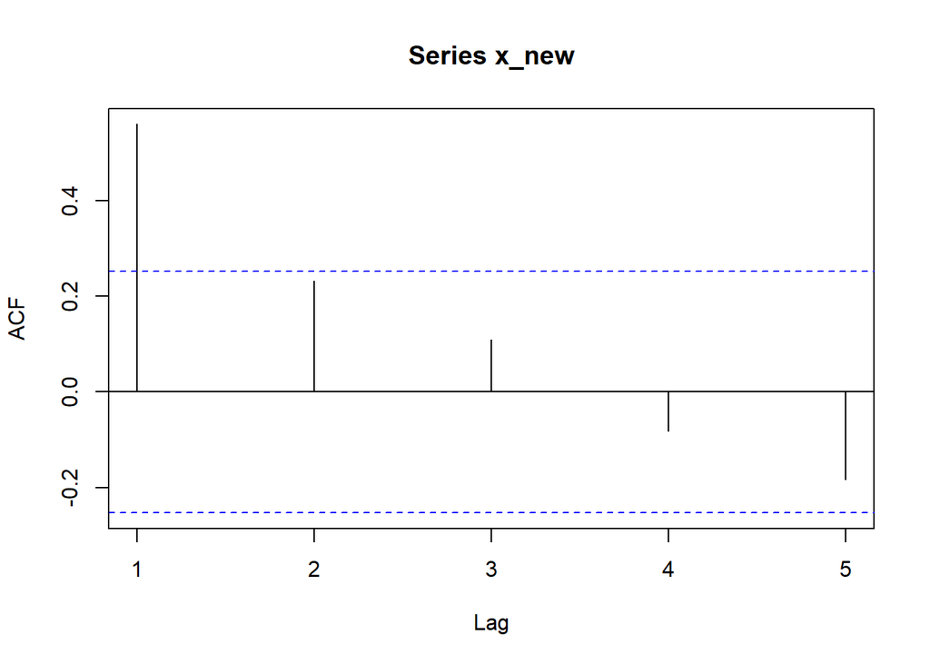

```r
set.seed(5678)
n <- 60
theta <- 0.5
x_new <- arima.sim(model = list(ma = theta), n = n, sd = 1)
acf_x_new <- acf(x_new, lag.max = 5, plot = TRUE)
```

```r
acf_x_new
```

```
##
## Autocorrelations of series 'x_new', by lag
##
##      1      2      3      4      5
##  0.560  0.232  0.110 -0.082 -0.184
```

```r
r1_new <- acf_x_new$acf[1]
r1_new
```

```
## [1] 0.5600134
```

We repeat the simulation with a different seed for the random number generator. The sample autocorrelation at lag 1 for the new simulation is:

$$r_1^{\text{new}} = 0.5600134$$

As in part (b), the theoretical value of the autocorrelation at lag 1 for the MA(1) process with $\theta = 0.5$ is:

$$\rho_1 = 0.4$$

Thus, the difference between the new sample autocorrelation $r_1^{\text{new}}$ and the theoretical value $\rho_1$ is:

$$\text{Difference} = r_1^{\text{new}} - \rho_1 = 0.5600134 - 0.4 =
0.1600134$$

The standard error of the sample autocorrelation at lag 1 for a sample size of $n = 60$ remains the same as in part (b):

$$\text{SE}(r_1) = \frac{0.79}{\sqrt{60}} \approx 0.102$$

We can express the difference in terms of the standard error:

$$\frac{\text{Difference}}{\text{SE}(r_1)} = \frac{0.1600134}{0.102}
\approx 1.569$$

The difference between the new sample autocorrelation $r_1^{\text{new}} = 0.5600134$ and the theoretical value $\rho_1 = 0.4$ is approximately 1.569 standard errors. This implies a larger deviation from the theoretical value compared to the previous simulation in part (b), where the deviation was about 0.31 standard errors.

The precision of the sample autocorrelation estimate depends on the specific sample selected(same $\theta$ and $n$). The new simulation resulted in a sample autocorrelation $r_1^{\text{new}} = 0.5600134$ that deviates more from the theoretical value of $0.4$ than the previous sample did. This demonstrates the variability in sample estimates due to random sampling, and suggests that larger deviations from the theoretical value are possible even with the same process parameters.

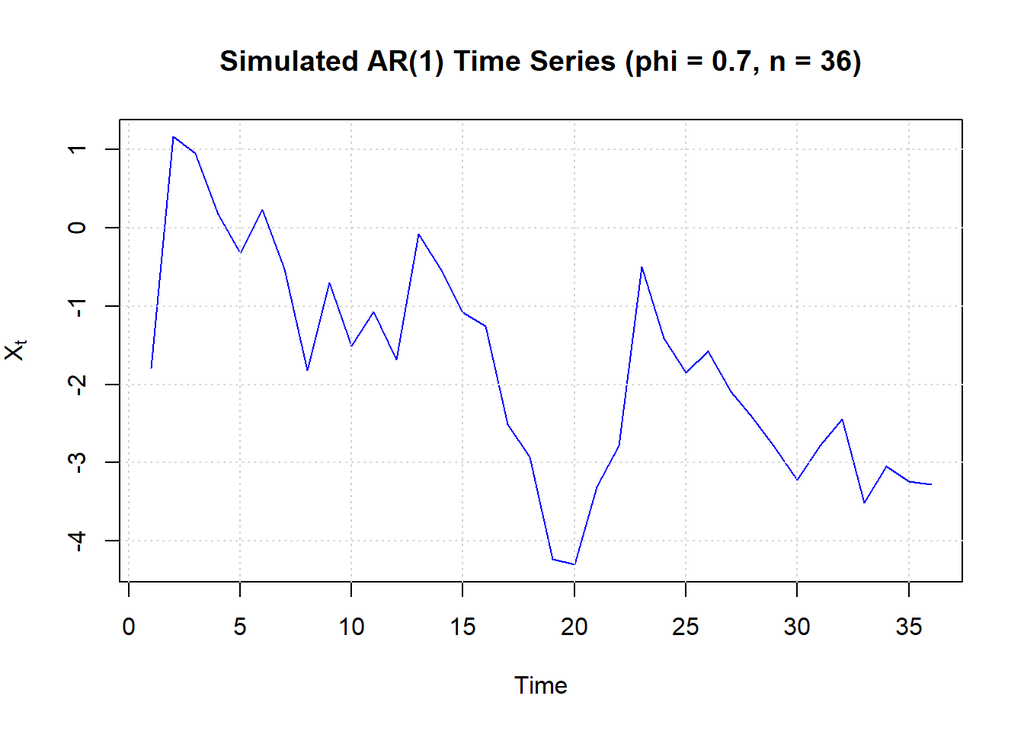

```r
set.seed(1234)
n <- 36
phi <- 0.7
x <- arima.sim(model = list(ar = phi), n = n, sd = 1)

plot(x, type = "l", main = "Simulated AR(1) Time Series (phi = 0.7, n = 36)",
xlab = "Time", ylab = expression(X[t]), col = "blue")
grid()
```

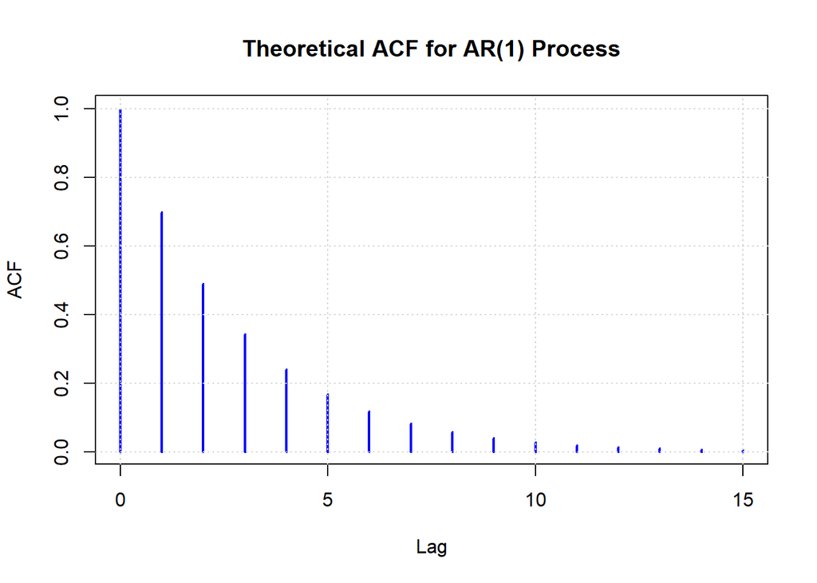

```r
phi <- 0.7
n_lags <- 15
lags <- 0:n_lags

rho_theoretical <- phi^lags

plot(lags, rho_theoretical, type = "h", lwd = 2, col = "blue",
     main = "Theoretical ACF for AR(1) Process",
     xlab = "Lag", ylab = "ACF")
grid()
```

For an AR(1) process, the theoretical autocorrelation function at lag $k$ is given by:

$$\rho_k = \phi^k$$

Thus, the theoretical autocorrelation for lag $k$ can be computed as:

$$\rho_1 = \phi^1 = 0.7$$
$$\rho_2 = \phi^2 = 0.7^2 = 0.49$$
$$\rho_3 = \phi^3 = 0.7^3 = 0.343$$
$$\rho_4 = \phi^4 = 0.7^4 = 0.2401$$
$$\rho_5 = \phi^5 = 0.7^5 = 0.16807$$
And so on, with the autocorrelation decaying exponentially as $\phi^k$ for increasing values of $k$.

To visualize the ACF, we can plot $\rho_k$ for values of $k$ from 0 to 15, since the autocorrelations become negligible after a certain point.

The plot shows how the autocorrelation function decays with increasing lag, with values approaching zero as $k$ increases. For the AR(1) model, this decay follows the pattern of $\phi^k$.

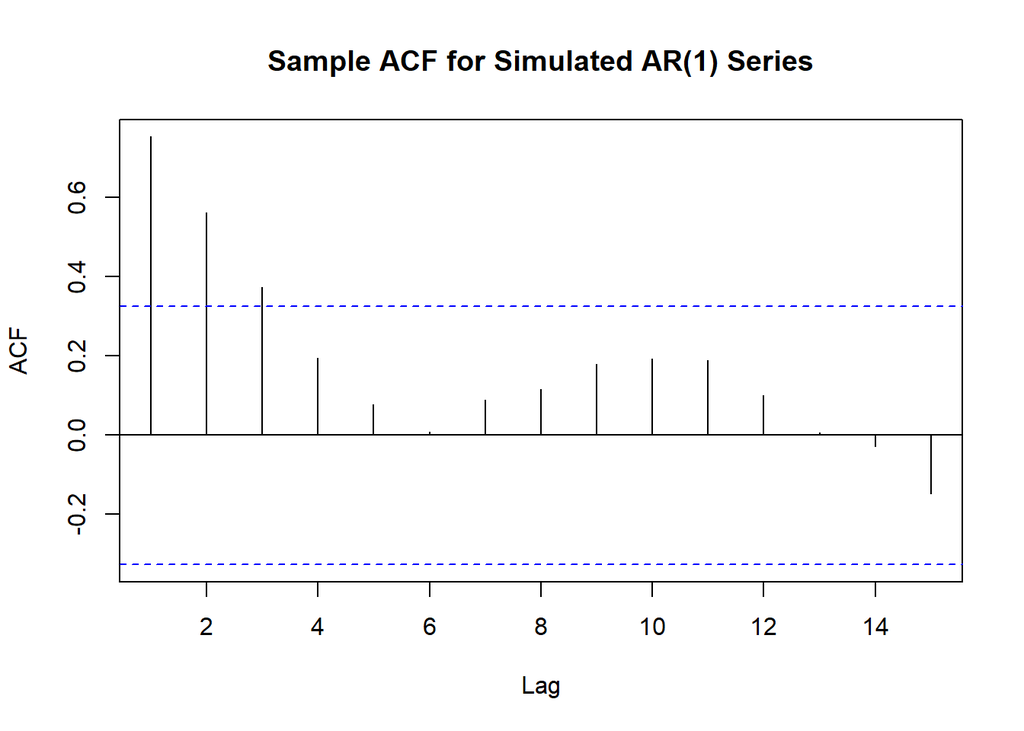

```r
set.seed(1234)
n <- 36
x_ar1 <- arima.sim(model = list(ar = phi), n = n)

acf(x_ar1, lag.max = 15, main = "Sample ACF for Simulated AR(1) Series")
```

The sample ACF obtained from the simulation matches the theoretical pattern closely for smaller lags. However, some variation in the sample ACF values can be seen due to the randomness in the simulation. This variation becomes more significant as the lag increases (after Lag 6). But, the general trend still follow the exponential decay characteristic of an AR(1) process.

The theoretical partial autocorrelation function (PACF) for an AR(1) model can be derived using the Yule-Walker equations. For an AR(1) process with parameter $\phi$, the PACF at lag $k$, denoted $\phi_k$, is:

$$\phi_k =
\begin{cases}
\phi & \text{if } k = 1 \\
0 & \text{if } k > 1
\end{cases}$$

For an AR(1) model with $\phi = 0.7$, the theoretical PACF is:

$$\phi_1 = 0.7, \quad \phi_2 = 0, \quad \phi_3 = 0, \dots$$

Thus, for this AR(1) process:

- The PACF at lag 1 is equal to $\phi = 0.7$.
- The PACF at lag 2 and higher lags is equal to 0.

This is a characteristic feature of AR(1) processes: the PACF cuts off after lag 1, indicating that only the first lag of the autocorrelation function has a direct influence, and higher lags have no additional influence on the current value.

This is because direct information beyond lag 1 is already captured by the first lag.

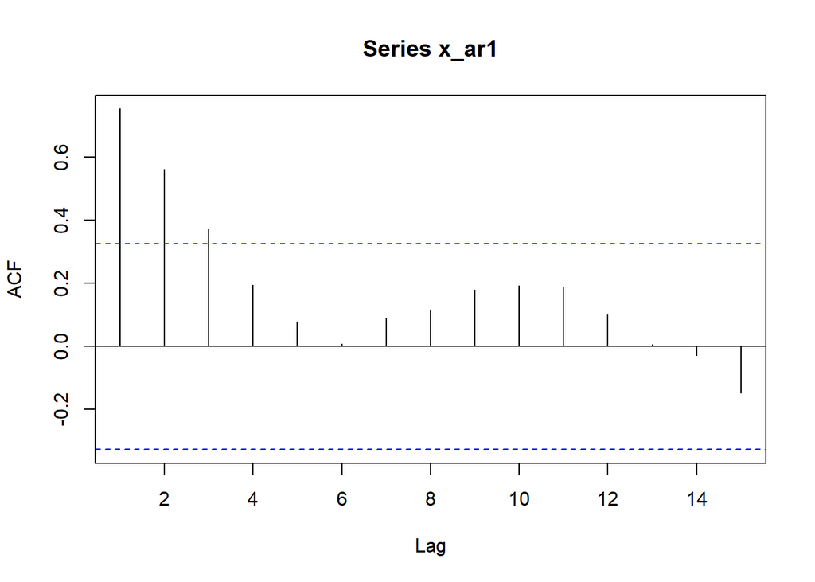

```r
acf_x_ar1 <- acf(x_ar1, lag.max = 15, plot = TRUE)
```

```r
r1_sample <- acf_x_ar1$acf[1]
r1_sample
```

```
## [1] 0.7538475
```

The theoretical autocorrelation at lag 1 for an AR(1) process with $\phi = 0.7$ is:

$$\rho_1 = \frac{\phi}{1} = 0.7$$

From the R simulation, the sample autocorrelation at lag 1 is:

$$r_1^{\text{sample}} = 0.7538475$$

Using the large-sample standard error from Exhibit 6.1 for $\phi = 0.7$ and $n = 36$, we calculate the standard error of the sample autocorrelation at lag 1:

$$\text{SE}(r_1) = \frac{0.71}{\sqrt{n}} = \frac{0.71}{\sqrt{36}} =
\frac{0.71}{6} \approx 0.1183$$

The difference between the sample and theoretical autocorrelation is:

$$\text{Difference} = r_1^{\text{sample}} - \rho_1 = 0.7538475 - 0.7 =
0.0538475$$

To quantify this difference in terms of standard errors:

$$\frac{\text{Difference}}{\text{SE}(r_1)} = \frac{0.0538475}{0.1183}
\approx 0.456$$

Since the difference of 0.0538 is less than 1 standard error, the sample autocorrelation at lag 1 is within the expected range of variability for large samples. Therefore, we conclude that the sample autocorrelation closely matches the theoretical autocorrelation. The sample ACF obtained from the simulation matches the theoretical pattern closely, particularly for smaller lags.

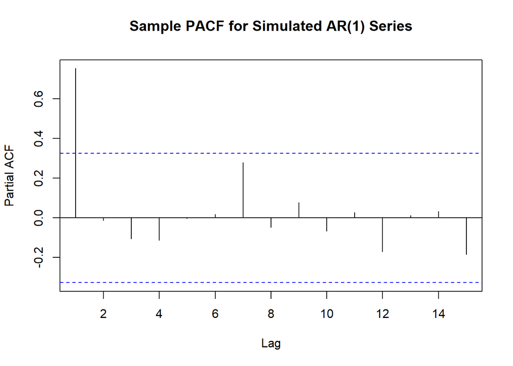

```r
pacf(x_ar1, lag.max = 15, main = "Sample PACF for Simulated AR(1) Series")
```

```r
pacf_theoretical <- c(0.7, rep(0, n_lags))
pacf_theoretical
```

```
##  [1] 0.7 0.0 0.0 0.0 0.0 0.0 0.0 0.0 0.0 0.0 0.0 0.0 0.0 0.0 0.0 0.0
```

From the PACF plot, we observe the following patterns:

1. A significant spike at lag 1, aligning with the theoretical expectation.
2. Partial autocorrelations at lags > 1 are close to zero, confirming the AR(1) structure.

Next, we calculate the large-sample standard error for the PACF at lag 1, which is reported on page 115. The large-sample standard error for the PACF at lag 1 is given by:

$$\text{SE}(\text{PACF}_1) = \frac{1}{\sqrt{n}} = \frac{1}{\sqrt{36}} =
\frac{1}{6} \approx 0.1667$$

We then compare the sample PACF at lag 1 to the theoretical value for the AR(1) process with $\phi = 0.7$, which is expected to be 0.7. For the simulated series, assume the PACF at lag 1 from the plot is approximately 0.75.

The difference between the sample PACF at lag 1 and the theoretical value (0.7) is:

$$\text{Difference} = \text{PACF}_1^{\text{sample}} - \phi =
\text{PACF}_1^{\text{sample}} - 0.7$$

Substituting the values:

$$\text{Difference} = 0.75 - 0.7 = 0.05$$

To quantify this difference in terms of the standard error:

$$\frac{\text{Difference}}{\text{SE}(\text{PACF}_1)} = \frac{0.05}{0.1667}
\approx 0.3$$

Since the difference is less than 1 standard error, the sample PACF at lag 1 is within the expected range of variability for large samples, and we can conclude that the sample PACF aligns well with the theoretical PACF.

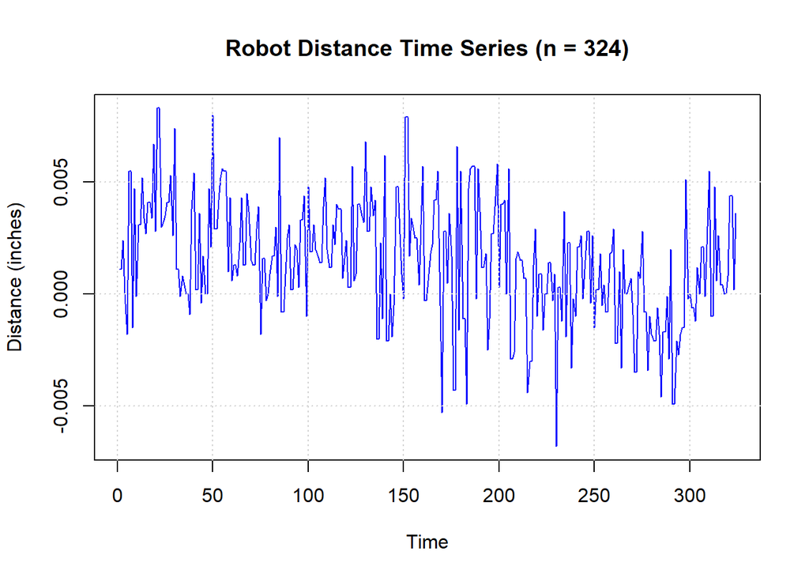

```r
data(robot)
plot(robot, type = "l", main = "Robot Distance Time Series (n = 324)",
     xlab = "Time", ylab = "Distance (inches)", col = "blue")
grid()
```

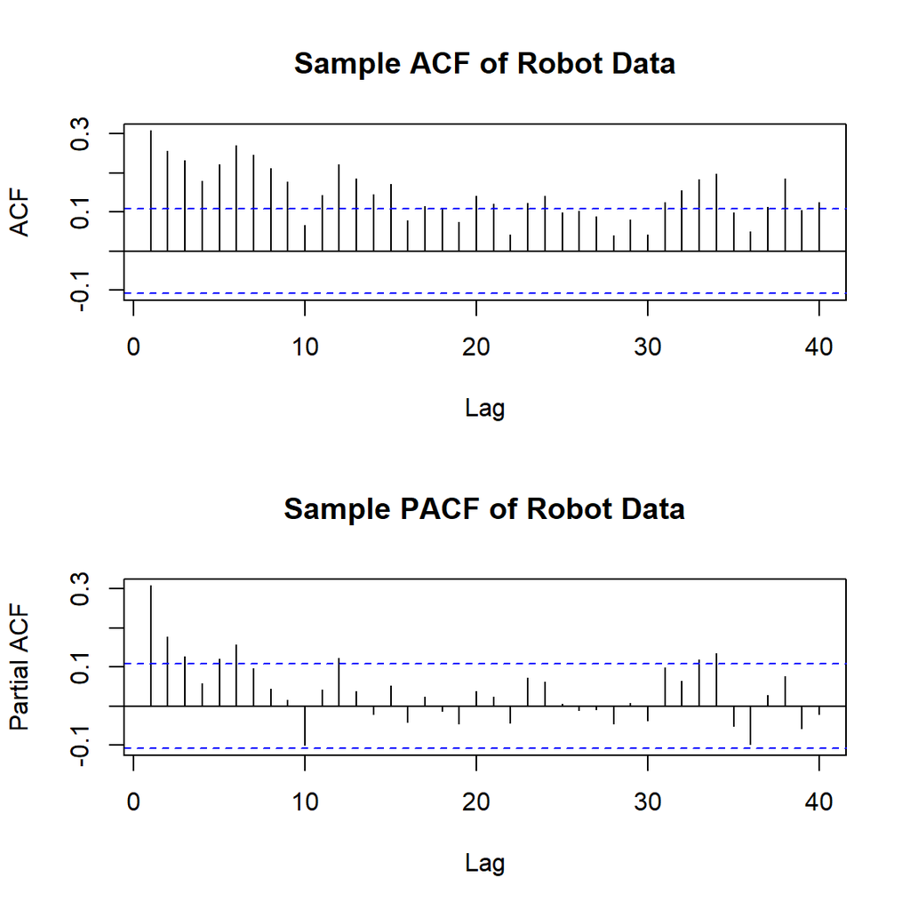

```r
par(mfrow = c(2, 1))
acf(robot, main = "Sample ACF of Robot Data", lag.max = 40)
pacf(robot, main = "Sample PACF of Robot Data", lag.max = 40)
```

In a stationary series, the ACF typically drops to zero quickly. However, the persistent high autocorrelations here suggest nonstationarity, likely due to a unit root (e.g., AR(1) with coefficient near 1 or ARIMA(0,1,0)).

```r
eacf(robot, ar.max = 7, ma.max = 7)
```

```
## AR/MA
##   0 1 2 3 4 5 6 7
## 0 x x x x x x x x
## 1 x o o o o o o o
## 2 x x o o o o o o
## 3 x x o o o o o o
## 4 x x x x o o o o
## 5 x x x o o o o o
## 6 x o o o o x o o
## 7 x o o x o x x o
```

The first row (AR(0)) shows all Xs, indicating the raw series has significant autocorrelations at all MA orders. As AR order increases, a triangle of 0s forms, with the vertex at AR(1), MA(1), suggesting an ARMA(1,1) model. This implies that after fitting an AR(1), an MA(1) term removes remaining autocorrelation.

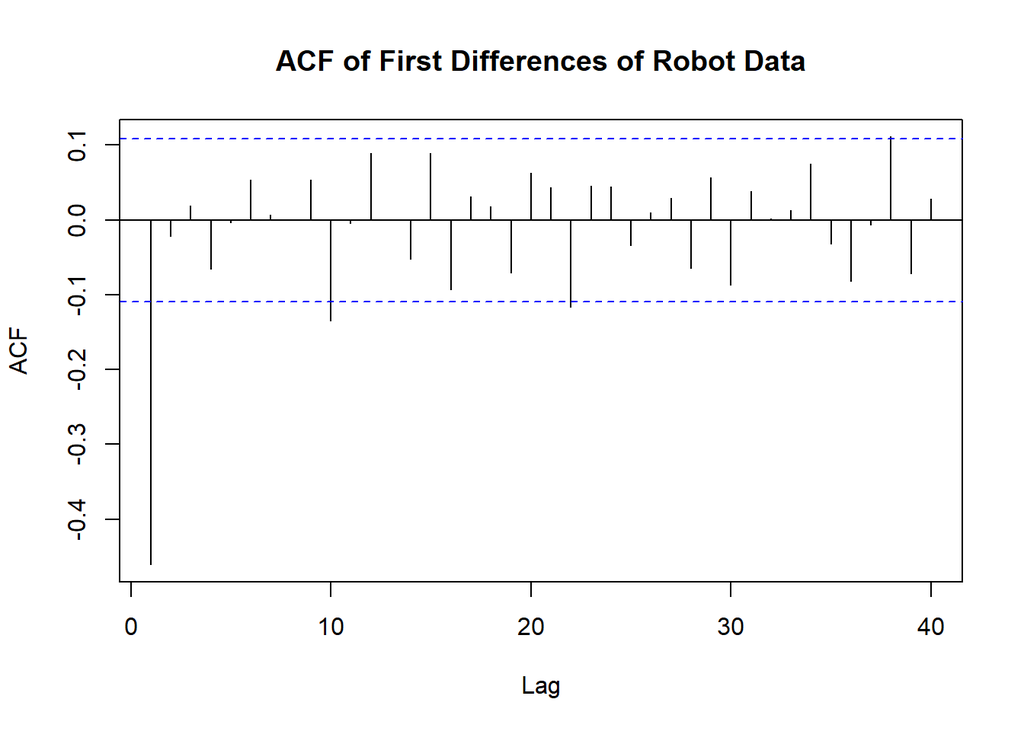

```r
acf(diff(robot), main = "ACF of First Differences of Robot Data", lag.max = 40)
```

```r
data(larain)
log_rain <- log(larain + 0.01)
eacf(log_rain, ar.max = 7, ma.max = 7)
```

```
## AR/MA
##   0 1 2 3 4 5 6 7
## 0 o o o o o o o o
## 1 o o o o o o o o
## 2 x x o o o o o o
## 3 x o o o o o o o
## 4 x o o o o o o o
## 5 x x x x x o o o
## 6 x x o o x o o o
## 7 x o x o o o o o
```

There is no consistent pattern of significant autocorrelations across higher-order AR or MA terms, which would be expected in a more structured time series.

To explore further, we plot the ACF:

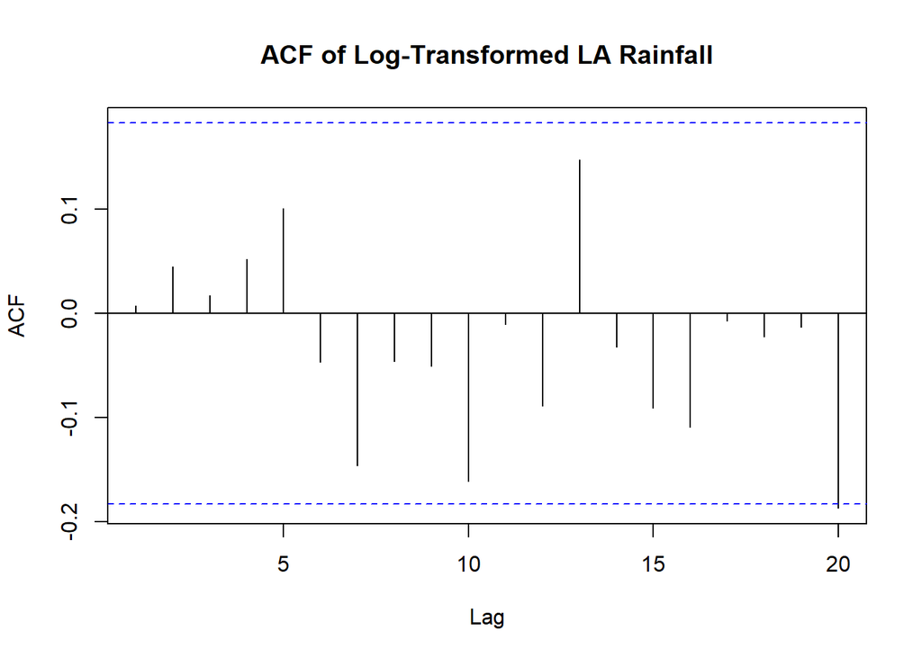

```r
acf_val<-acf(log_rain, main = "ACF of Log-Transformed LA Rainfall", lag.max = 20)
```

```r
acf_val
```

```
##
## Autocorrelations of series 'log_rain', by lag
##
##      1      2      3      4      5      6      7      8      9     10     11
##  0.007  0.045  0.017  0.052  0.101 -0.047 -0.146 -0.046 -0.051 -0.161 -0.010
##     12     13     14     15     16     17     18     19     20
## -0.088  0.148 -0.032 -0.091 -0.109 -0.007 -0.022 -0.013 -0.187
```

Most values are small. These suggest only weak, possibly random fluctuations, with no clear dependence structure.

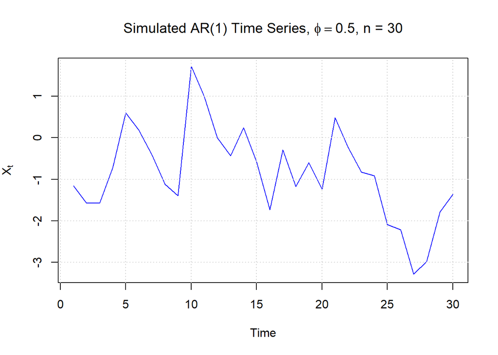

```r
set.seed(1234)
n <- 30
phi <- 0.5
x <- arima.sim(model = list(ar = phi), n = n, sd = 1)
plot(x, type = "l",
main = expression("Simulated AR(1) Time Series, " * phi == 0.5 * ", n = 30"),
xlab = "Time", ylab = expression(X[t]), col = "blue")
grid()
```

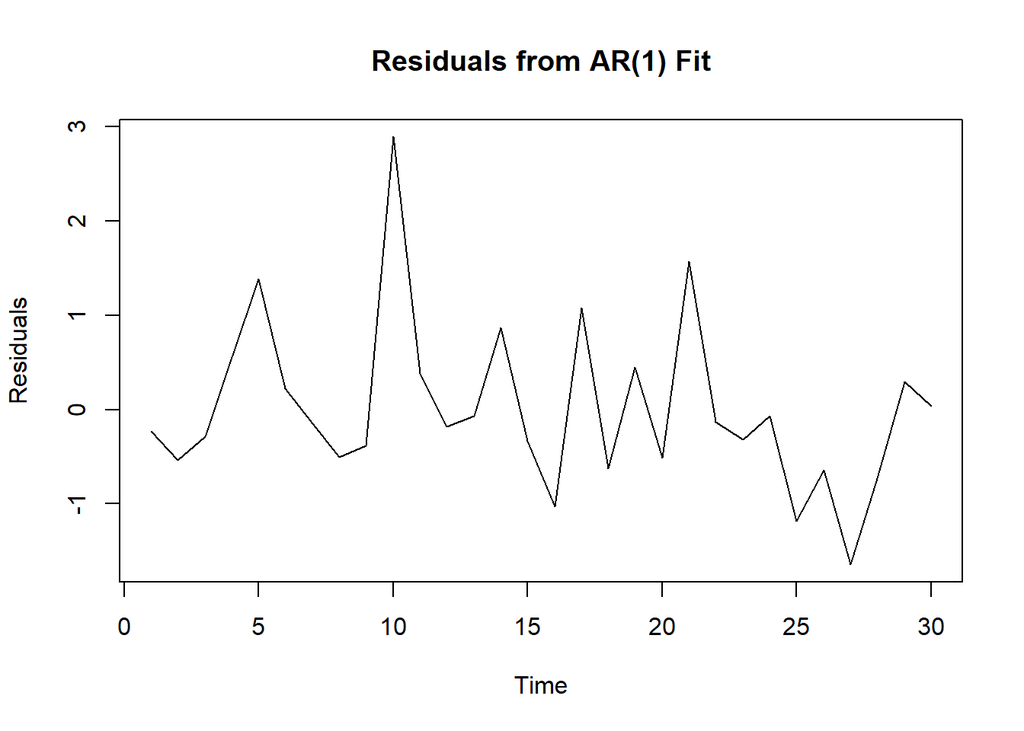

```r
fit <- arima(x, order = c(1, 0, 0))
residuals <- residuals(fit)
ts.plot(residuals, main = "Residuals from AR(1) Fit", ylab = "Residuals")
```

The time series plot of the residuals appears to show no obvious trend or autocorrelation. This supports the AR(1) model specification.

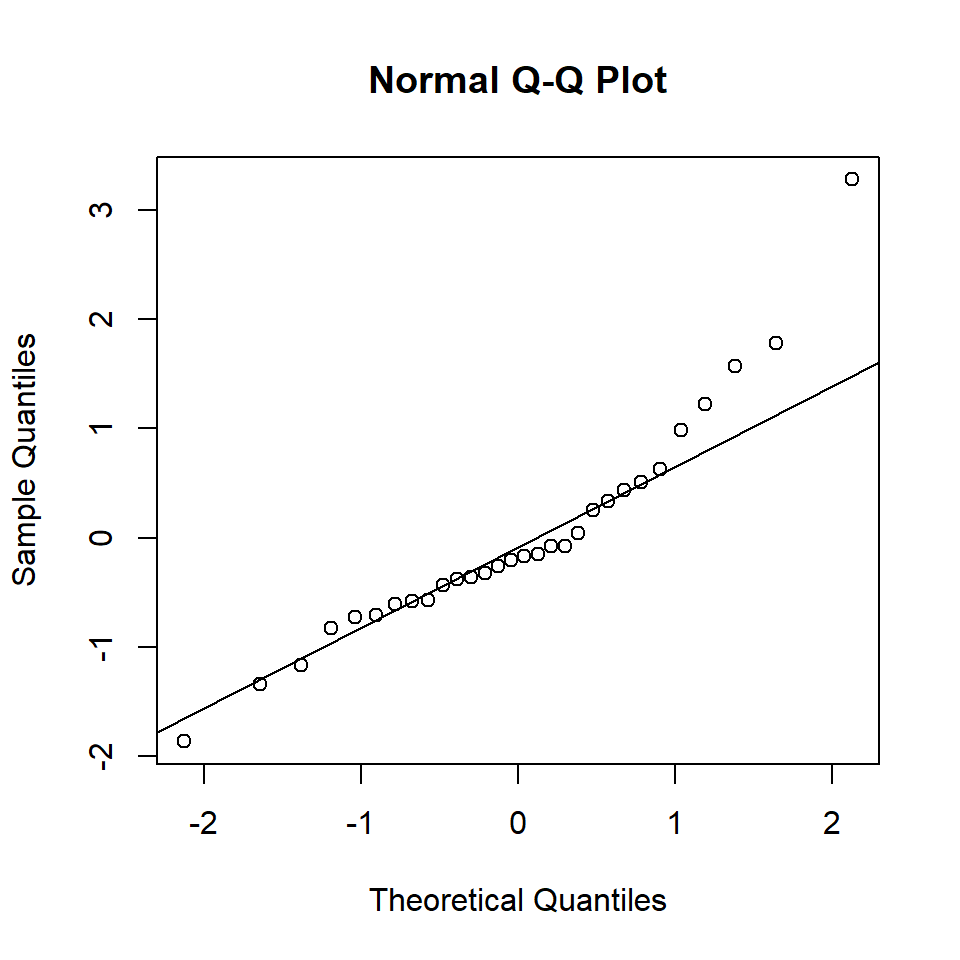

```r
standardized_resid <- residuals / sqrt(fit$sigma2)
qqnorm(standardized_resid)
qqline(standardized_resid)
```

The standardized residuals lie approximately along the straight line in the Q-Q plot, it suggests that the residuals are approximately normally distributed. This supports the AR(1) assumption of Gaussian white noise.

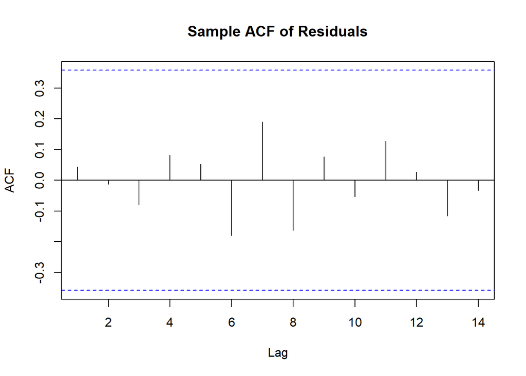

```r
acf(residuals, main = "Sample ACF of Residuals")
```

The ACF plot of the residuals shows all autocorrelations within the 95% confidence bounds, this implies the residuals behave like white noise, validating the AR(1) model specification.

```r
Box.test(residuals, lag = 8, type = "Ljung-Box")
```

```
##
##  Box-Ljung test
##
## data:  residuals
## X-squared = 4.6023, df = 8, p-value = 0.7991
```

The p-value is much greater than 0.05, so we fail to reject the null hypothesis that the residuals are uncorrelated. This supports the AR(1) specification.

[figure not shown]

```r
set.seed(1234)
n <- 36
theta <- -0.5
x_ma1 <- arima.sim(model = list(ma = theta), n = n, sd = 1)

plot(x, type = "l",
main = expression("Simulated MA(1) Time Series, " * theta == 0.5 * ", n = 36"),
xlab = "Time", ylab = expression(X[t]), col = "blue")
grid()
```

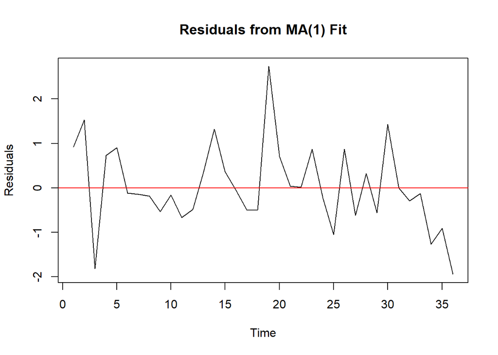

```r
fit_ma1 <- arima(x_ma1, order = c(0, 0, 1))
ts.plot(residuals(fit_ma1), main = "Residuals from MA(1) Fit", ylab = "Residuals")
abline(h = 0, col = "red")
```

The time series plot of residuals appears to show no systematic pattern or trend. This supports the assumption that the MA(1) model is correctly specified.

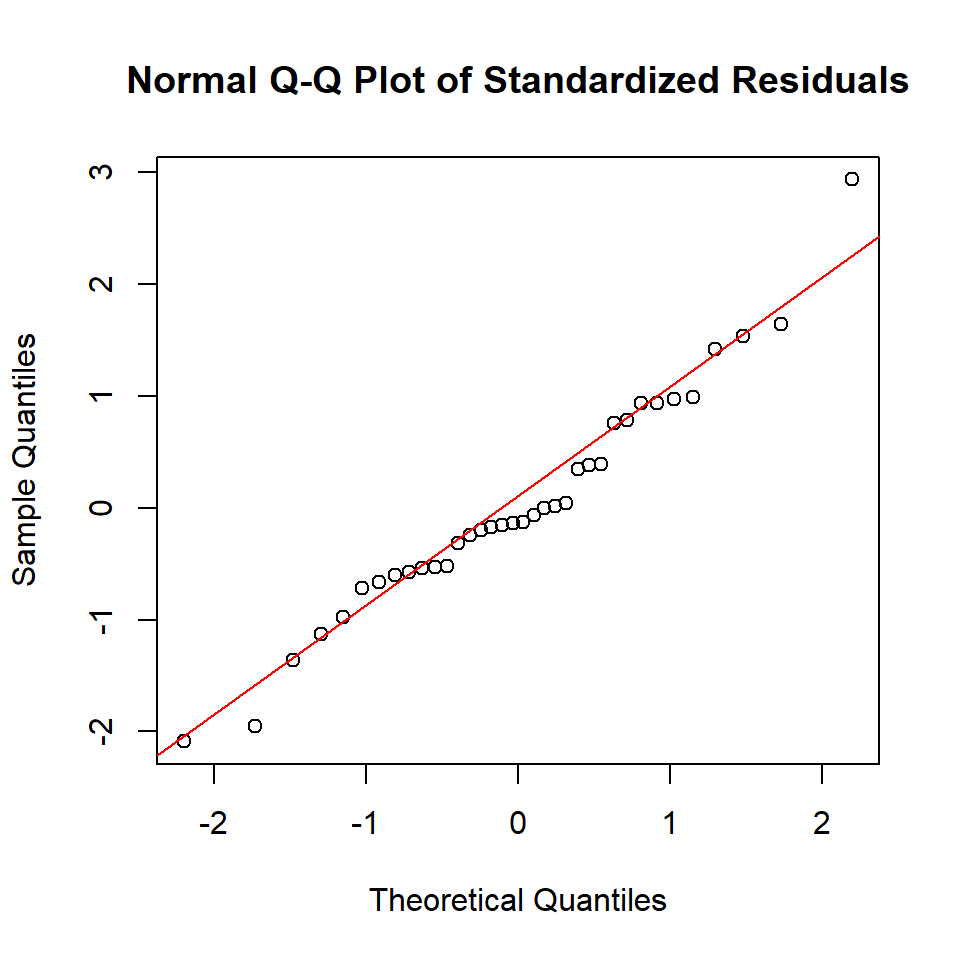

```r
resid_std <- residuals(fit_ma1) / sqrt(fit_ma1$sigma2)
qqnorm(resid_std, main = "Normal Q-Q Plot of Standardized Residuals")
qqline(resid_std, col = "red")
```

The Q-Q plot shows that the standardized residuals fall approximately along the reference line, indicating that the residuals are roughly normally distributed. This supports the MA(1) specification.

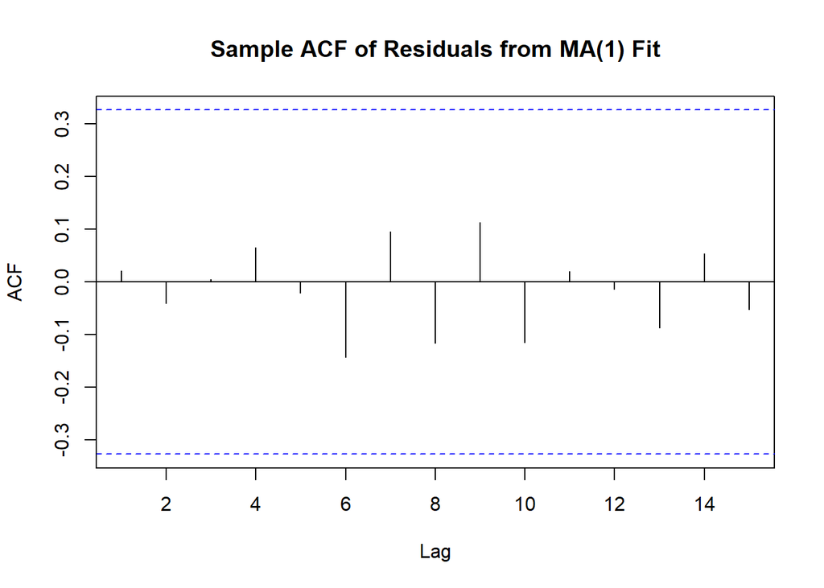

```r
acf(residuals(fit_ma1), main = "Sample ACF of Residuals from MA(1) Fit")
```

The ACF of the residuals shows that all autocorrelations fall within the 95% confidence bounds, indicating no remaining autocorrelation. This supports the MA(1) specification.

```r
Box.test(residuals(fit_ma1), lag = 6, type = "Ljung-Box")
```

```
##
##  Box-Ljung test
##
## data:  residuals(fit_ma1)
## X-squared = 1.2155, df = 6, p-value = 0.9761
```

Since the p-value ($p = 0.9761$) is much greater than 0.05, we fail to reject the null hypothesis that the residuals are white noise. This provides strong support that the MA(1) model is an appropriate fit for the data.